# STA141AHW1

Sam Tsoi

Due: 10/31/2017

### 1.

Unzip and load the airfare dataset. Convert the columns to appropriate data types, then separate table 1a and 6 into different variables (to help you avoid double counting). You don’t need to write an answer for this question, but please mark the code for this question in the appendix.

Answer is attached in the code.

### 2.

```
##
##  1996  1997  1998  1999  2000  2001  2002  2003  2004  2005  2006  2007
## 28783 30085 30187 30214 30389 29672 29501 29349 30032 30608 30299 29925
##  2008  2009  2010  2011  2012  2013  2014  2015  2016  2017
## 29687 29513 30046 30321 30302 30338 30970 30610 28739  7500
```

```
##
##      1      2      3      4
## 158891 158969 161004 158206
```

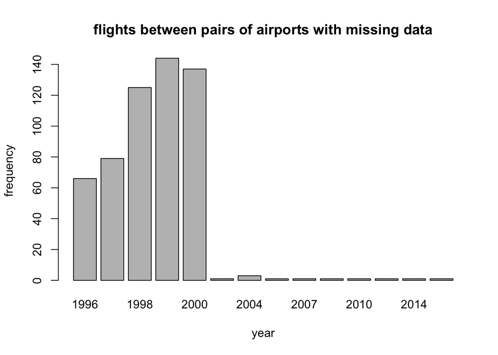

Additionally, it is broken down by quarters, with frequencies as shown:

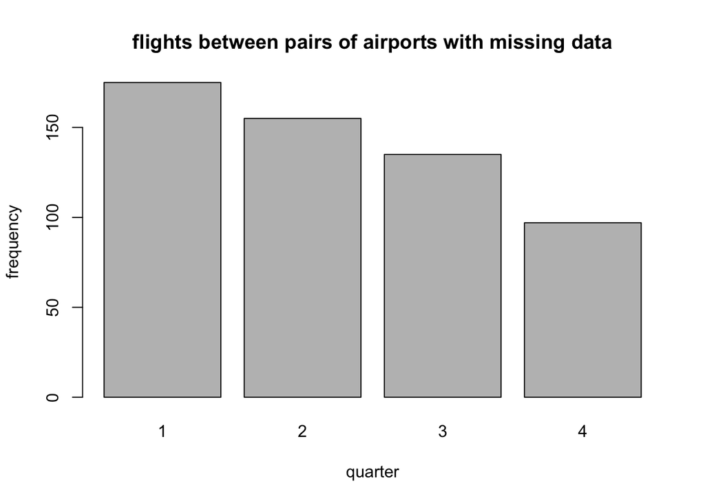

It seems like earlier years have more missing data than later years. However, I do not believe that it is because data from earlier years has error. This is probably because data collecting gets more advanced as time goes on, not because there was something wrong with the flights earlier on. Additionally, it seems like number of missing data decreases as quarter goes on. I feel like this is random, as this is different from the results for flights between pairs of cities (shown later on) and also the frequency between each quarter does not differ significantly. Further exploration and investigation would be needed in order to make a more appropriate conclusion.

For flights between pairs of cities (named as table 6 in my data), there is a total of 568 flights (rows) that did not have data (has with more than 6 NAs). Each year and frequency is shown:

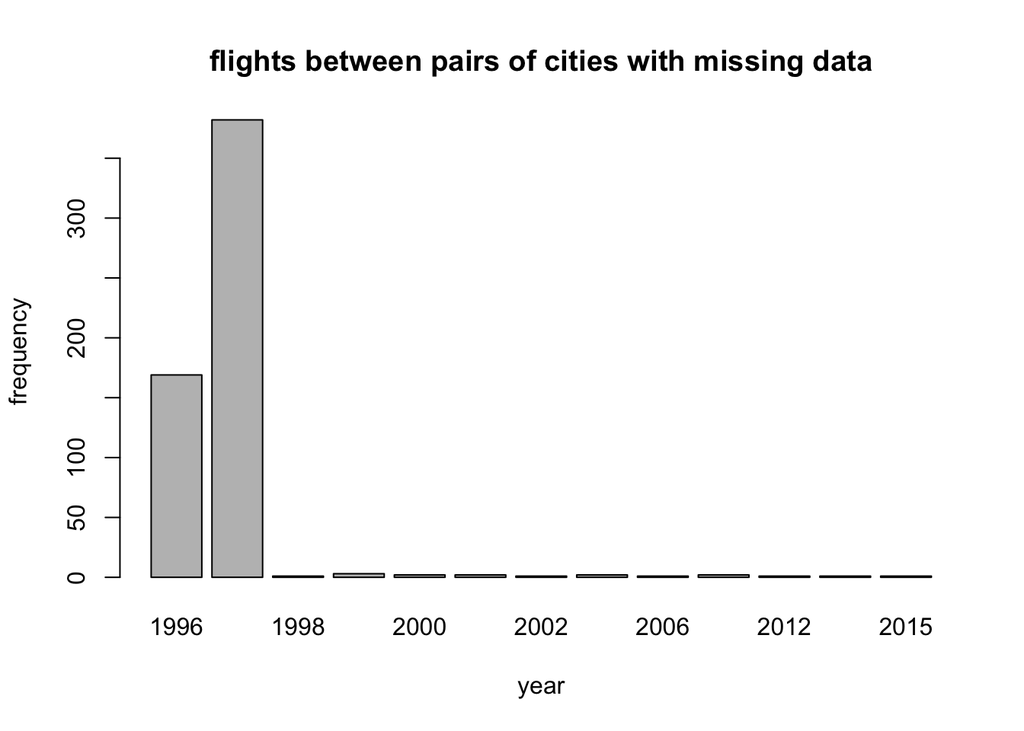

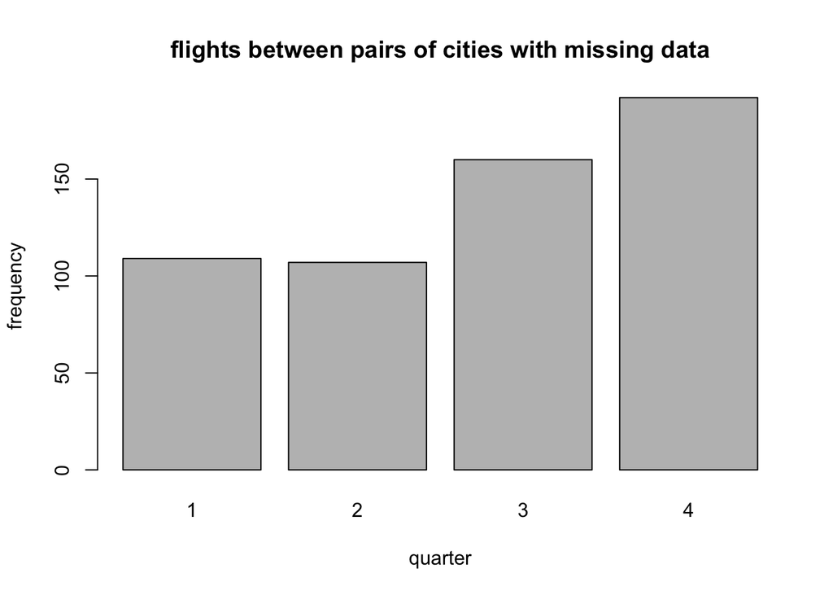

So, it seems like most data from flights between pairs of cities is missing from year 1996 and 1997. As mentioned, this is probably because data collecting gets more thorough and advanced as time goes on. There could have been something happened in 1997 that made their data collecting much more thorough. For flights between pairs of cities, it does not seem like the number of missing data decreases over quarters. Instead, it increases, and there is the most missing data by the fourth quarter. This might be because the fourth quarter (around holiday time), there is a high frequency of flights in general and it might be more difficult to manage all the data for all flights during this time. Further exploration and investigation could be done in order to make a more appropriate conclusion.

### 3.

```
##  [1] Chicago, IL
##  [2] Dallas/Fort Worth, TX
##  [3] Denver, CO
##  [4] Las Vegas, NV
##  [5] Los Angeles, CA (Metropolitan Area)
##  [6] Miami, FL (Metropolitan Area)
##  [7] New York City, NY (Metropolitan Area)
##  [8] Orlando, FL
##  [9] Phoenix, AZ
## [10] San Francisco, CA (Metropolitan Area)
## [11] Washington, DC (Metropolitan Area)
## 317 Levels: Aberdeen, SD Abilene, TX Albany, GA ... West Palm Beach/Palm Beach, FL
```

These are the cities in 2017 with 0 connections (least connections) when in and out connections are combined:

```
##  [1] Branson, MO              Bullhead City, AZ
##  [3] Carlsbad, CA             Dickinson, ND
##  [5] Farmington, NM           Hickory, NC
##  [7] Hyannis, MA              International Falls, MN
##  [9] Inyokern, CA             Jamestown, NY
## [11] Kinston, NC              Lewisburg, WV
## [13] Longview, TX             Macon, GA
## [15] Marathon, FL             Martha's Vineyard, MA
## [17] Modesto, CA              Muskegon, MI
## [19] Nantucket, MA            Naples, FL
## [21] Oxnard/Ventura, CA       Parkersburg, WV
## [23] Pellston, MI             Port Angeles, WA
## [25] Presque Isle/Houlton, ME Provincetown, MA
## [27] Reading, PA              Rhinelander, WI
## [29] Rockland, ME             St. Augustine, FL
## [31] Texarkana, AR            Tupelo, MS
## 317 Levels: Aberdeen, SD Abilene, TX Albany, GA ... West Palm Beach/Palm Beach, FL
```

I believe that there are more cities that do not have connections whatsoever but I disregarded data with missing data (NAs) for in and out connections. I do not believe that these cities with 0 connections mean that there are no flights for these cities, but instead, there might be something wrong with collecting information for these cities. Something I noticed is that the cities that have fewer connections are cities that are less well-known. For example, Chicago, Dallas/Fort Worth, Denver, Los Angeles, Phoenix, etc. are all major cities, whereas Bullhead City and Carlsbad are not as internationally well-known. There may be less flight connections to these cities as well as maybe there are less resources to collect data at these cities since they are smaller.

```
##  [1] Atlanta, GA (Metropolitan Area)
##  [2] Chicago, IL
##  [3] Dallas/Fort Worth, TX
##  [4] Las Vegas, NV
##  [5] Los Angeles, CA (Metropolitan Area)
##  [6] New York City, NY (Metropolitan Area)
##  [7] Orlando, FL
##  [8] Phoenix, AZ
##  [9] San Francisco, CA (Metropolitan Area)
## [10] Washington, DC (Metropolitan Area)
## 317 Levels: Aberdeen, SD Abilene, TX Albany, GA ... West Palm Beach/Palm Beach, FL
```

These are the cities in 2007 with 0 connections (least connections) when in and out connections are combined:

[output not shown]

The 10 cities that have the most connections to other cities in 1997 (I am only displaying results for quarter 1, since 2017 only has data for quarter 1) are:

```
##  [1] Atlanta, GA (Metropolitan Area)
##  [2] Chicago, IL
##  [3] Dallas/Fort Worth, TX
##  [4] Denver, CO
##  [5] Los Angeles, CA (Metropolitan Area)
##  [6] New York City, NY (Metropolitan Area)
##  [7] Orlando, FL
##  [8] Phoenix, AZ
##  [9] San Francisco, CA (Metropolitan Area)
## [10] Washington, DC (Metropolitan Area)
## 317 Levels: Aberdeen, SD Abilene, TX Albany, GA ... West Palm Beach/Palm Beach, FL
```

These are the cities in 1997 with 0 connections (least connections) when in and out connections are combined:

```
##  [1] Branson, MO             Dickinson, ND
##  [3] Dubuque, IA             Eau Claire, WI
##  [5] Escanaba, MI            Grand Island, NE
##  [7] Hagerstown, MD          Hancock/Houghton, MI
##  [9] Hickory, NC             Hyannis, MA
## [11] International Falls, MN Joplin, MO
## [13] Kinston, NC             Lewisburg, WV
## [15] Longview, TX            Mammoth Lakes, CA
## [17] Manhattan/Ft. Riley, KS Martha's Vineyard, MA
## [19] Muskegon, MI            Niagara Falls, NY
## [21] Ogdensburg, NY          Owensboro, KY
## [23] Paducah, KY             Pellston, MI
## [25] Plattsburgh, NY         Portsmouth, NH
## [27] Provincetown, MA        Provo, UT
## [29] Punta Gorda, FL         Rockland, ME
## [31] Sanford, FL             Sault Ste. Marie, MI
## [33] St. Augustine, FL       St. George, UT
## [35] Tupelo, MS
## 317 Levels: Aberdeen, SD Abilene, TX Albany, GA ... West Palm Beach/Palm Beach, FL
```

From the data of quarter 1 from 2007 and 1997, there are more cities with 0 connections from earlier years than in later years. This might be because data collection is more thorough and technology gets more advanced as time goes on. As mentioned, it makes sense that the cities with most connections are internationally well-known. It is interesting that Atlanta was on top 10 most connections for both 1997 2007, but not in 2017.

### 4.

How has the approximate number of total passengers per quarter changed over the years? Create a graphic to show this and comment on patterns you see. Some quarters have a sharp decline in number of total passengers. What might explain these?

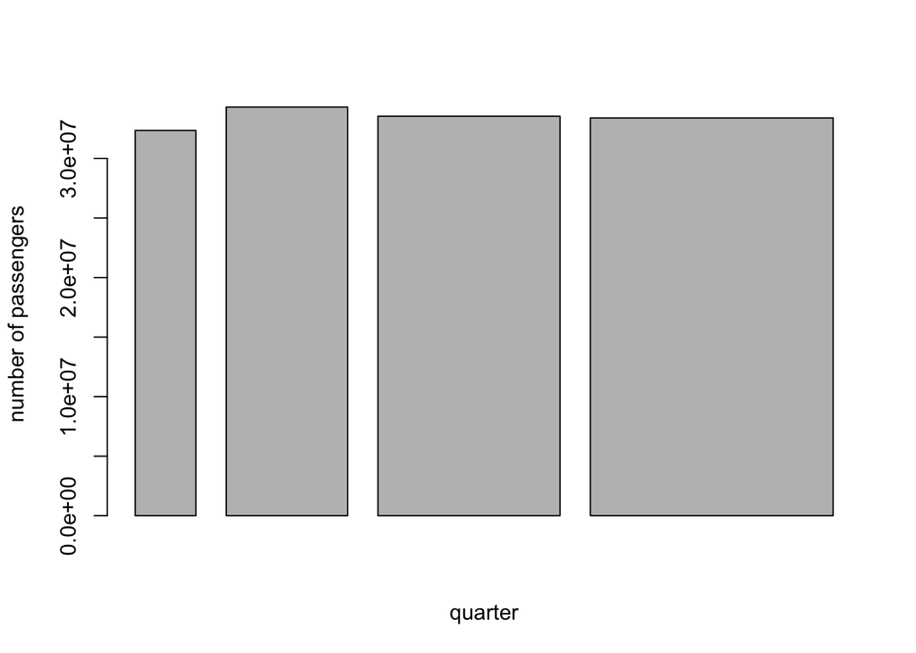

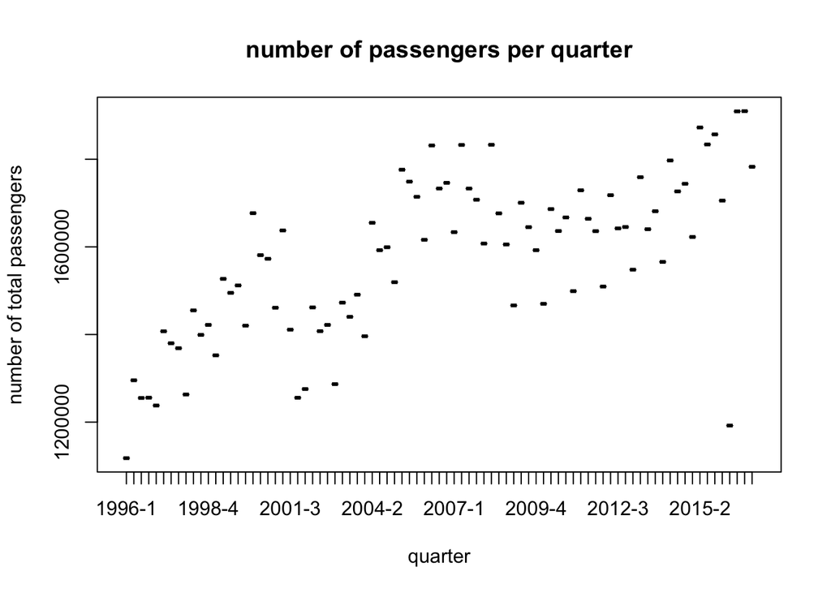

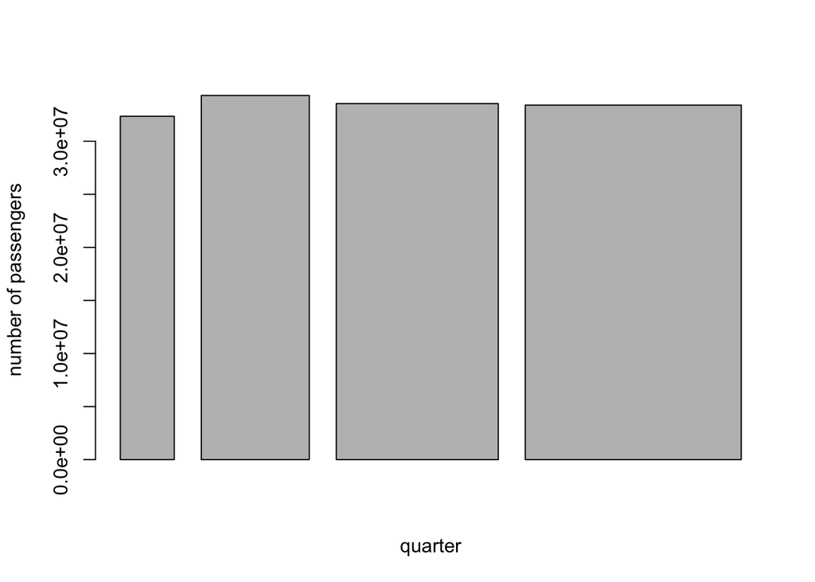

Answer is attached in the code. The real17_fare is compared to the most recent nominal dollar updated (year 2017, quarter 3).

6. How have airfares changed over time? Use fares in real Q1 2017 dollars to investigate this graphically. Comment on patterns you see.

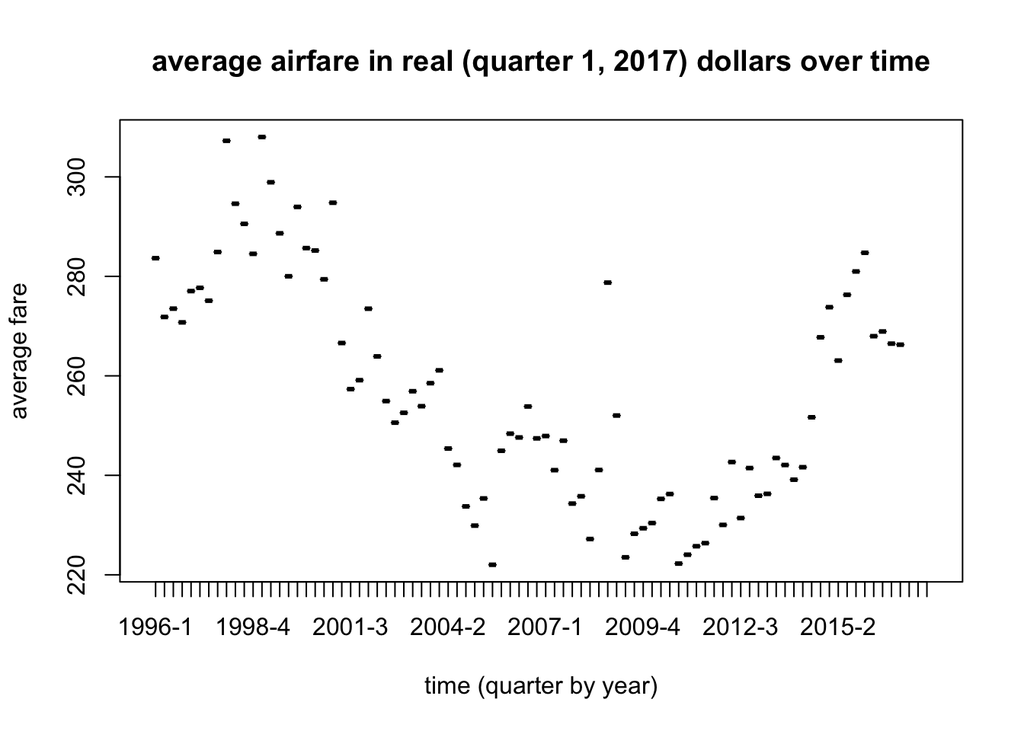

   Now that the dollar amount is adjusted, we can see that overtime, average fare seemed to have fluctuated. The airfare was very high in the earlier years and kept decreasing until around 2010. This might not be a coincidence, and I believe that this might have to do with the 2008 recession. Airfare prices might have been at an all-time low because demand might have been low. After this time, however, the prices of airfare seem to have increased again as the economy improved.

To make more sense of how airfare changed by quarter, I zoomed into quarters:

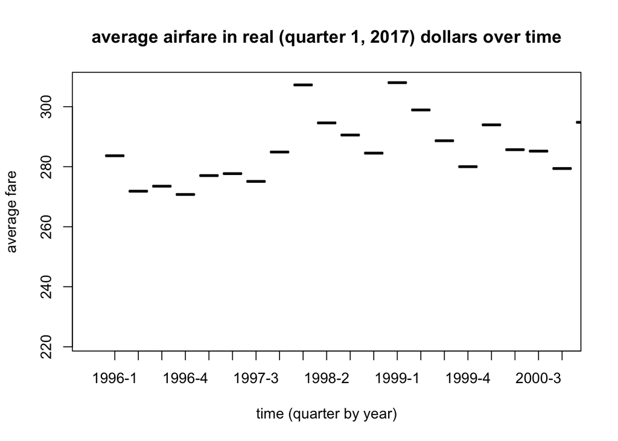

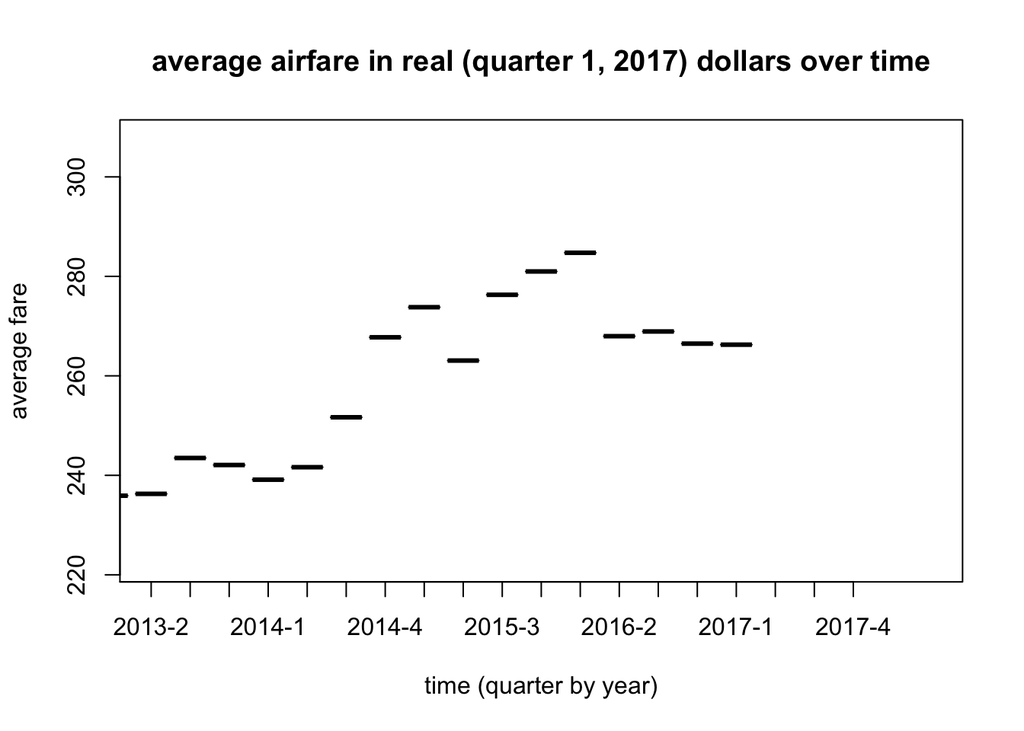

7. For 2015, what is the relationship between fare and distance? Use table 1a to investigate this visually and by using an appropriate statistical model or test. Comment on what you can infer from each and whether there is any disagreement. State the assumptions, use diagnostics to check whether they hold, and comment on how this affects your conclusions. Repeat your analysis with table 6. Comment on differences between your two results and why these occur.

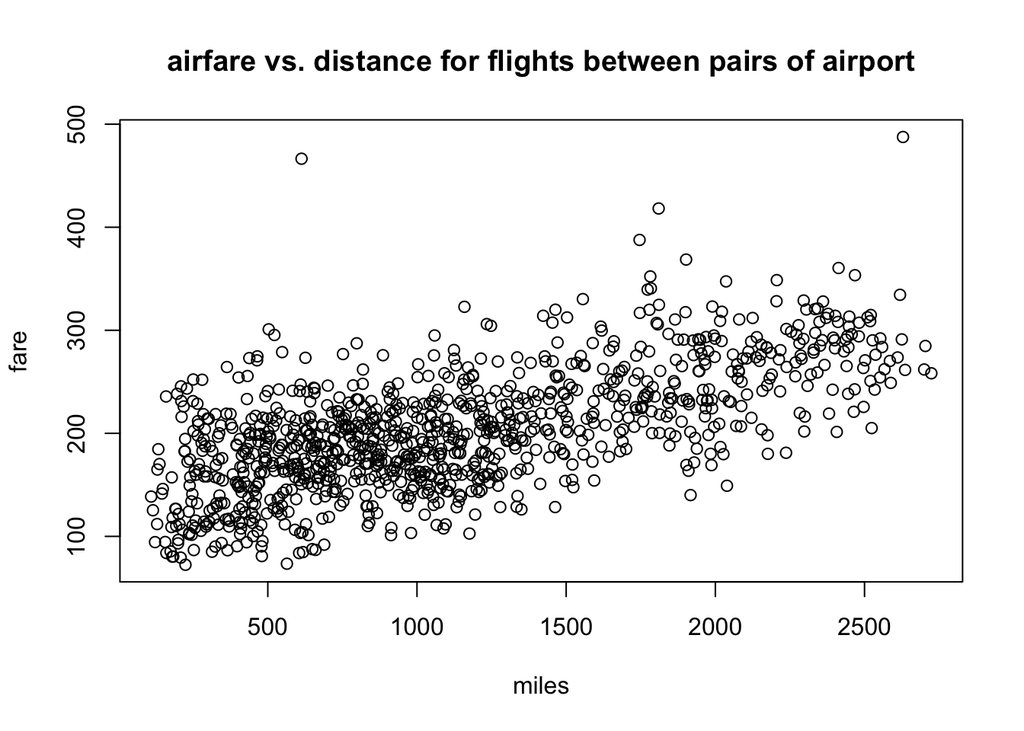

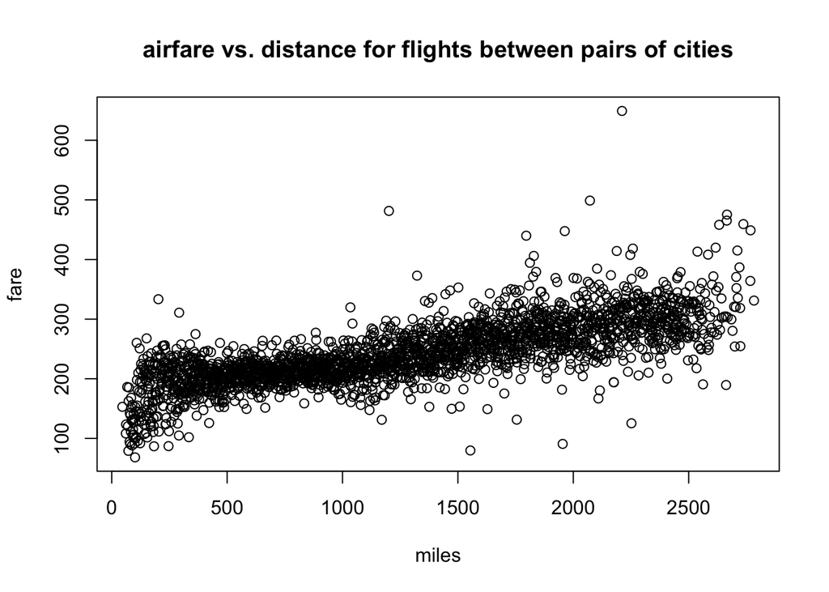

Using linear regression on table 1a and table 6, respectively:

```
##
## Call:
## lm(formula = aggregate(table1a$fare ~ table1a$miles, table1a,
##     FUN = mean))
##
## Coefficients:
##    (Intercept)  `table1a$fare`
##       -325.380           7.171
```

```
##
## Call:
## lm(formula = aggregate(table6$fare ~ table6$miles, table6, FUN = mean))
##
## Coefficients:
##   (Intercept)  `table6$fare`
##     -1124.724          9.964
```

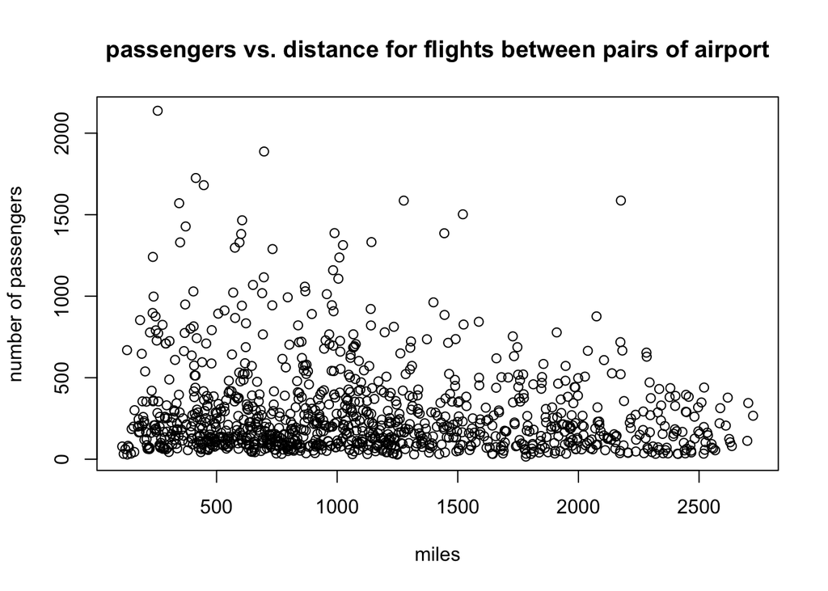

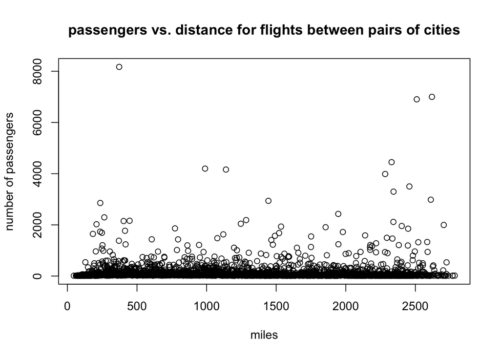

Using linear regression on table 1a and table 6, respectively:

```
##
## Call:
## lm(formula = aggregate(table1a$passengers ~ table1a$miles, table1a,
##     FUN = mean))
##
## Coefficients:
##          (Intercept)  `table1a$passengers`
##            1210.0620               -0.2948
```

```
##
## Call:
## lm(formula = aggregate(table6$passengers ~ table6$miles, table6,
##     FUN = mean))
##
## Coefficients:
##         (Intercept)  `table6$passengers`
##           1.283e+03            3.156e-02
```

Looiking at the graph, there does not seem to be a relationship between miles and number of passengers for either of the graphs.

9. For 2015, identify city pairs where the carrier with the largest market share has fares below the average for that city pair. Investigate these using graphics, statistics, or models (as you see fit). Comment on patterns you find.
10. Use table 1a to compare Sacramento (SMF), Oakland (OAK), San Francisco (SFO), and San Jose (SJC). How do fares differ between these airports? Which airport has the most long-distance connections and how does this compare to the others? Do these results differ by year?

### Citations:

Looked on Piazza for tips

Consulted dicussion notes

### Code Appendix

```r
#1
data <- read.csv("~/Desktop/airfare.csv")
data$city_id1 <- as.factor(data$city_id1)
data$city_id1 <-as.factor(data$city_id2)
i = split(data, data$table)
table1a = i$`1a`
table6 = i$`6`
#2
table(data$year)
table(data$quarter)
data$NAs <- apply(is.na(data), 1, sum)
table1a$NAs <- apply(is.na(table1a), 1, sum)
table6$NAs <- apply(is.na(table6), 1, sum)

sevenNAs1ayear <- table(table1a$year[table6$NAs > 6])
barplot(sevenNAs1ayear,xlab= "year", ylab = "frequency", main ="flights between pairs of airports with missing data")
sevenNAs1aquarter<-table(table1a$quarter[table6$NAs > 6])
barplot(sevenNAs1aquarter,xlab= "quarter", ylab = "frequency", main ="flights between pairs of airports with missing data")
sevenNAs6year <- table(table6$year[table6$NAs > 6])
barplot(sevenNAs6year,xlab= "year", ylab = "frequency", main ="flights between pairs of cities with missing data")
sevenNAs6quarter <- table(table6$quarter[table6$NAs > 6])
barplot(sevenNAs6quarter,xlab= "quarter", ylab = "frequency", main ="flights between pairs of cities with missing data")
#3
cities12017<- table(table6$city1[table6$year %in% "2017"])
cities22017 <-table(table6$city2[table6$year %in% "2017"])
mergedCities2017 <- merge(cities12017,cities22017, by="Var1")
mergedCities2017$connections <- rowSums(mergedCities2017[, c("Freq.x", "Freq.y")], na.rm=T)
mostConnections2017 <- sort(mergedCities2017$connections, decreasing = T)[1:10]
mergedCities2017$Var1[mergedCities2017$connections %in% mostConnections2017]
leastConnections2017 <- sort(mergedCities2017$connections, decreasing = F)
leastConnections2017 <- mergedCities2017$Var1[mergedCities2017$connections == 0]
leastConnections2017
cities12007<- table(table6$city1[table6$year %in% "2007" & table6$quarter == 1])
cities22007 <-table(table6$city2[table6$year %in% "2007" & table6$quarter == 1])
mergedCities2007 <- merge(cities12007,cities22007, by="Var1")
mergedCities2007$connections <- rowSums(mergedCities2007[, c("Freq.x", "Freq.y")], na.rm=T)
mostConnections2007 <- sort(mergedCities2007$connections, decreasing = T)[1:10]
mergedCities2007$Var1[mergedCities2007$connections %in% mostConnections2007]
leastConnections2007 <- sort(mergedCities2007$connections, decreasing = F)
leastConnections2007 <- mergedCities2007$Var1[mergedCities2007$connections == 0]
leastConnections2017
cities11997<- table(table6$city1[table6$year %in% "1997" & table6$quarter == 1])
cities21997 <-table(table6$city2[table6$year %in% "1997" & table6$quarter == 1])
mergedCities1997 <- merge(cities11997,cities21997, by="Var1")
mergedCities1997$connections <- rowSums(mergedCities1997[, c("Freq.x", "Freq.y")], na.rm=T)
mostConnections1997 <- sort(mergedCities1997$connections, decreasing = T)[1:10]
mergedCities1997$Var1[mergedCities1997$connections %in% mostConnections1997]
leastConnections1997 <- sort(mergedCities1997$connections, decreasing = F)
leastConnections1997 <- mergedCities1997$Var1[mergedCities1997$connections == 0]
leastConnections1997
#4
tab1a <- aggregate(table1a$passengers ~ table1a$quarter+table1a$year, table1a, FUN = sum)
tab <- aggregate(data$passengers ~ data$quarter+data$year, data, FUN = sum)
pass <- aggregate(data$passengers ~ data$quarter, data, FUN = sum)
barplot(pass$`data$passengers`, pass$`data$quarter`, xlab = "quarter", ylab = "number of passengers")
data$quarterbyyear <- paste(data$year,data$quarter,sep="-")
data$quarterbyyear <- as.factor(data$quarterbyyear)
passengerByQ <- aggregate(data$passengers ~ data$quarterbyyear, data, FUN = sum, na.rm=T)
plot(passengerByQ, type="p", xlab = "quarter", ylab = "number of total passengers", main ="number of passengers per quarter")

pass <- aggregate(data$passengers ~ data$quarter, data, FUN = sum)
barplot(pass$`data$passengers`, pass$`data$quarter`, xlab = "quarter", ylab = "number of passengers")
#5
library(readxl)
cpi <- read_xlsx("~/Desktop/cpi_1996_2017.xlsx")
cpi <-cpi[12:33,0:13] #gets rid of unnecessary data
cpi <- data.frame(cpi)

cpi <- cpi[,seq(4,13,3)] #getting 4 numbers, one for each quarter
frame1 <- data.frame(year=rep(c(1996:2017),times=4), quarter=rep(c(1:4),each=22), cpi = stack(cpi))
new <- merge(frame1,table6, by.x=c("year","quarter"), all=TRUE)
new$cpi.values<- as.numeric(new$cpi.values)
new$real17_fare <- new$lg_fare * (new$cpi.values[new$year == 2017 & new$quarter == 3]/new$cpi.values)
#6
new$real17_fareq1 <- new$lg_fare * (200.091/new$cpi.values)
new$quarterbyyear <- paste(new$year,new$quarter,sep="-")
new$quarterbyyear <- as.factor(new$quarterbyyear)
plot(aggregate(new$real17_fareq1 ~ new$quarterbyyear, new, FUN = mean), xlab="time (quarter by year)", ylab = "average fare", main="average airfare in real (quarter 1, 2017) dollars over time")
plot(aggregate(new$real17_fareq1 ~ new$quarterbyyear, new, FUN = mean), type = "l", xlab="time (quarter by year)", ylab = "average fare", main="average airfare in real (quarter 1, 2017) dollars over time", xlim=c(0,20))
plot(aggregate(new$real17_fareq1 ~ new$quarterbyyear, new, FUN = mean), type = "l", xlab="time (quarter by year)", ylab = "average fare", main="average airfare in real (quarter 1, 2017) dollars over time", xlim=c(70,90))
#7
fare1a <- aggregate(table1a$fare ~ table1a$miles, table1a, FUN=mean)
plot(fare1a, xlab = "miles", ylab="fare", main="airfare vs. distance for flights between pairs of airport")
plot(aggregate(table6$fare ~ table6$miles, table6, FUN=mean), xlab = "miles", ylab="fare", main="airfare vs. distance for flights between pairs of cities")
lm(aggregate(table1a$fare ~ table1a$miles, table1a, FUN=mean))
lm(aggregate(table6$fare ~ table6$miles, table6, FUN=mean))
#8
plot(aggregate(table1a$passengers ~ table1a$miles, table1a, FUN=mean), xlab = "miles", ylab="number of passengers", main="passengers vs. distance for flights between pairs of airport")
plot(aggregate(table6$passengers ~ table6$miles, table6, FUN=mean), xlab = "miles", ylab="number of passengers", main="passengers vs. distance for flights between pairs of cities")
lm(aggregate(table1a$passengers ~ table1a$miles, table1a, FUN=mean))
lm(aggregate(table6$passengers ~ table6$miles, table6, FUN=mean))
```